# Report

Atharva and Mohit

April 25, 2018

Loading data form the csv file

```r
data <- read.csv('./modelEvaluation_4_20_cleaned_1.csv',stringsAsFactors= T)
summary(data)
```

```
##       NUM
##  Min.   : 1.000
##  1st Qu.: 3.000
##  Median : 7.000
##  Mean   : 7.548
##  3rd Qu.:11.500
##  Max.   :17.000
##
##                                                                   PROJ
##  F15a_construction_meeting_minutes_application                      : 2
##  F13a_LA_Commons_upgradeof_website                                  : 1
##  F13a_LiveRiot_Video_Editing_System_and_socialNetworking_enhancement: 1
##  F13a_OnlineWedding_Management_System                               : 1
##  F13a_Surgery_Assist                                                : 1
##  F13a_Yanomamo Interactive CDROM                                    : 1
##  (Other)                                                            :24
##   Effort_Norm      Norm_Factor         KSLOC            Effort
##  Min.   : 135.5   Min.   :0.6694   Min.   : 0.552   Min.   : 103.0
##  1st Qu.: 468.6   1st Qu.:0.9747   1st Qu.: 2.228   1st Qu.: 285.5
##  Median : 781.8   Median :1.1927   Median : 4.402   Median : 759.0
##  Mean   :1465.0   Mean   :1.2523   Mean   : 4.757   Mean   :1139.1
##  3rd Qu.:2431.6   3rd Qu.:1.4471   3rd Qu.: 7.336   3rd Qu.:1392.9
##  Max.   :5850.4   Max.   :1.9079   Max.   :12.263   Max.   :8224.7
##  NA's   :8        NA's   :8        NA's   :1
##  Effort_Norm_UCP     Path_Num      UseCase_Num    Total_Degree
##  Min.   : 140.6   Min.   : 27.0   Min.   : 5.0   Min.   :0
##  1st Qu.: 344.1   1st Qu.: 55.0   1st Qu.: 8.0   1st Qu.:0
##  Median : 652.0   Median : 91.0   Median :11.0   Median :0
##  Mean   :1008.1   Mean   :129.0   Mean   :13.1   Mean   :0
##  3rd Qu.:1546.8   3rd Qu.:143.5   3rd Qu.:17.0   3rd Qu.:0
##  Max.   :3217.0   Max.   :488.0   Max.   :26.0   Max.   :0
##  NA's   :8
##   Element_Num      Entity_Num    attribute_num    operation_num
##  Min.   : 59.0   Min.   : 0.00   Min.   :  0.00   Min.   :  0.00
##  1st Qu.:128.0   1st Qu.: 9.00   1st Qu.:  0.00   1st Qu.:  0.00
##  Median :183.0   Median :11.00   Median : 13.00   Median :  0.00
##  Mean   :209.6   Mean   :15.42   Mean   : 39.26   Mean   : 18.19
##  3rd Qu.:250.0   3rd Qu.:17.50   3rd Qu.: 57.50   3rd Qu.: 14.00
##  Max.   :555.0   Max.   :49.00   Max.   :221.00   Max.   :197.00
##
```

[output cut: 89 more lines]

```
##  Min.   : 77.92   Min.   :  9.64   Min.   :  9.64   Min.   : 270
##  1st Qu.:127.55   1st Qu.: 31.21   1st Qu.: 31.21   1st Qu.: 550
##  Median :165.00   Median : 56.93   Median : 56.93   Median : 910
##  Mean   :185.46   Mean   : 66.57   Mean   : 66.57   Mean   :1290
##  3rd Qu.:234.84   3rd Qu.: 86.61   3rd Qu.: 86.61   3rd Qu.:1435
##  Max.   :359.96   Max.   :191.64   Max.   :191.64   Max.   :4880
##
##      SWTII          SWTIII
##  Min.   : 290   Min.   : 214
##  1st Qu.: 825   1st Qu.: 650
##  Median :1244   Median : 982
##  Mean   :1851   Mean   :1473
##  3rd Qu.:2145   3rd Qu.:1716
##  Max.   :7234   Max.   :5780
##
```

## Preprocessing the data

Replacing all the NaN with the mean value.

```r
data$NUM = ifelse(is.na(data$NUM), ave(data$NUM, FUN = function(x) mean(x, na.rm = TRUE)),data$NUM)
data$PROJ = ifelse(is.na(data$PROJ), ave(data$PROJ, FUN = function(x) mean(x, na.rm = TRUE)),data$PROJ)
data$Effort_Norm = ifelse(is.na(data$Effort_Norm), ave(data$Effort_Norm, FUN = function(x) mean(x, na.rm = TRUE)),data$Effort_Norm)
data$Norm_Factor = ifelse(is.na(data$Norm_Factor), ave(data$Norm_Factor, FUN = function(x) mean(x, na.rm = TRUE)),data$Norm_Factor)
data$KSLOC = ifelse(is.na(data$KSLOC), ave(data$KSLOC, FUN = function(x) mean(x, na.rm = TRUE)),data$KSLOC)
data$Effort = ifelse(is.na(data$Effort), ave(data$Effort, FUN = function(x) mean(x, na.rm = TRUE)),data$Effort)
data$Effort_Norm_UCP = ifelse(is.na(data$Effort_Norm_UCP), ave(data$Effort_Norm_UCP, FUN = function(x) mean(x, na.rm = TRUE)),data$Effort_Norm_UCP)
data$Path_Num = ifelse(is.na(data$Path_Num), ave(data$Path_Num, FUN = function(x) mean(x, na.rm = TRUE)),data$Path_Num)
data$UseCase_Num = ifelse(is.na(data$UseCase_Num), ave(data$UseCase_Num, FUN = function(x) mean(x, na.rm = TRUE)),data$UseCase_Num)
data$Total_Degree = ifelse(is.na(data$Total_Degree), ave(data$Total_Degree, FUN = function(x) mean(x, na.rm = TRUE)),data$Total_Degree)
data$Element_Num = ifelse(is.na(data$Element_Num), ave(data$Element_Num, FUN = function(x) mean(x, na.rm = TRUE)),data$Element_Num)
data$Entity_Num = ifelse(is.na(data$Entity_Num), ave(data$Entity_Num, FUN = function(x) mean(x, na.rm = TRUE)),data$Entity_Num)
data$attribute_num = ifelse(is.na(data$attribute_num), ave(data$attribute_num, FUN = function(x) mean(x, na.rm = TRUE)),data$attribute_num)
data$operation_num = ifelse(is.na(data$operation_num), ave(data$operation_num, FUN = function(x) mean(x, na.rm = TRUE)),data$operation_num)
data$class_num = ifelse(is.na(data$class_num), ave(data$class_num, FUN = function(x) mean(x, na.rm = TRUE)),data$class_num)
data$Top_Level_Classes = ifelse(is.na(data$Top_Level_Classes), ave(data$Top_Level_Classes, FUN = function(x) mean(x, na.rm = TRUE)),data$Top_Level_Classes)
data$Average_Depth_Inheritance_Tree = ifelse(is.na(data$Average_Depth_Inheritance_Tree), ave(data$Average_Depth_Inheritance_Tree, FUN = function(x) mean(x, na.rm = TRUE)),data$Average_Depth_Inheritance_Tree)
data$Average_Number_Of_Children_Per_Base_Class = ifelse(is.na(data$Average_Number_Of_Children_Per_Base_Class), ave(data$Average_Number_Of_Children_Per_Base_Class, FUN = function(x) mean(x, na.rm = TRUE)),data$Average_Number_Of_Children_Per_Base_Class)
data$Number_Of_Inheritance_Relationships = ifelse(is.na(data$Number_Of_Inheritance_Relationships), ave(data$Number_Of_Inheritance_Relationships, FUN = function(x) mean(x, na.rm = TRUE)),data$Number_Of_Inheritance_Relationships)
data$Number_Of_Derived_Classes = ifelse(is.na(data$Number_Of_Derived_Classes), ave(data$Number_Of_Derived_Classes, FUN = function(x) mean(x, na.rm = TRUE)),data$Number_Of_Derived_Classes)
data$Number_Of_Classes_Inherited = ifelse(is.na(data$Number_Of_Classes_Inherited), ave(data$Number_Of_Classes_Inherited, FUN = function(x) mean(x, na.rm = TRUE)),data$Number_Of_Classes_Inherited)
data$Number_Of_Classes_Inherited_From = ifelse(is.na(data$Number_Of_Classes_Inherited_From), ave(data$Number_Of_Classes_Inherited_From, FUN = function(x) mean(x, na.rm = TRUE)),data$Number_Of_Classes_Inherited_From)
data$Number_Of_Children = ifelse(is.na(data$Number_Of_Children), ave(data$Number_Of_Children, FUN = function(x) mean(x, na.rm = TRUE)),data$Number_Of_Children)
data$Depth_Inheritance_Tree = ifelse(is.na(data$Depth_Inheritance_Tree), ave(data$Depth_Inheritance_Tree, FUN = function(x) mean(x, na.rm = TRUE)),data$Depth_Inheritance_Tree)
data$Coupling_Between_Objects = ifelse(is.na(data$Coupling_Between_Objects), ave(data$Coupling_Between_Objects, FUN = function(x) mean(x, na.rm = TRUE)),data$Coupling_Between_Objects)
data$para_num = ifelse(is.na(data$para_num), ave(data$para_num, FUN = function(x) mean(x, na.rm = TRUE)),data$para_num)
data$usage_num = ifelse(is.na(data$usage_num), ave(data$usage_num, FUN = function(x) mean(x, na.rm = TRUE)),data$usage_num)
data$real_num = ifelse(is.na(data$real_num), ave(data$real_num, FUN = function(x) mean(x, na.rm = TRUE)),data$real_num)
data$assoc_num = ifelse(is.na(data$assoc_num), ave(data$assoc_num, FUN = function(x) mean(x, na.rm = TRUE)),data$assoc_num)
data$externaloper_num = ifelse(is.na(data$externaloper_num), ave(data$externaloper_num, FUN = function(x) mean(x, na.rm = TRUE)),data$externaloper_num)
data$objectdata_num = ifelse(is.na(data$objectdata_num), ave(data$objectdata_num, FUN = function(x) mean(x, na.rm = TRUE)),data$objectdata_num)
data$avg_operation = ifelse(is.na(data$avg_operation), ave(data$avg_operation, FUN = function(x) mean(x, na.rm = TRUE)),data$avg_operation)
data$avg_attribute = ifelse(is.na(data$avg_attribute), ave(data$avg_attribute, FUN = function(x) mean(x, na.rm = TRUE)),data$avg_attribute)
data$avg_parameter = ifelse(is.na(data$avg_parameter), ave(data$avg_parameter, FUN = function(x) mean(x, na.rm = TRUE)),data$avg_parameter)
data$avg_instVar = ifelse(is.na(data$avg_instVar), ave(data$avg_instVar, FUN = function(x) mean(x, na.rm = TRUE)),data$avg_instVar)
data$FUNC_NA = ifelse(is.na(data$FUNC_NA), ave(data$FUNC_NA, FUN = function(x) mean(x, na.rm = TRUE)),data$FUNC_NA)
data$EI = ifelse(is.na(data$EI), ave(data$EI, FUN = function(x) mean(x, na.rm = TRUE)),data$EI)
data$INT = ifelse(is.na(data$INT), ave(data$INT, FUN = function(x) mean(x, na.rm = TRUE)),data$INT)
data$DM = ifelse(is.na(data$DM), ave(data$DM, FUN = function(x) mean(x, na.rm = TRUE)),data$DM)
data$CTRL = ifelse(is.na(data$CTRL), ave(data$CTRL, FUN = function(x) mean(x, na.rm = TRUE)),data$CTRL)
data$EXTCLL = ifelse(is.na(data$EXTCLL), ave(data$EXTCLL, FUN = function(x) mean(x, na.rm = TRUE)),data$EXTCLL)
data$TRAN_NA = ifelse(is.na(data$TRAN_NA), ave(data$TRAN_NA, FUN = function(x) mean(x, na.rm = TRUE)),data$TRAN_NA)
data$NT = ifelse(is.na(data$NT), ave(data$NT, FUN = function(x) mean(x, na.rm = TRUE)),data$NT)
data$Complex_UC = ifelse(is.na(data$Complex_UC), ave(data$Complex_UC, FUN = function(x) mean(x, na.rm = TRUE)),data$Complex_UC)
data$UEUCW = ifelse(is.na(data$UEUCW), ave(data$UEUCW, FUN = function(x) mean(x, na.rm = TRUE)),data$UEUCW)
data$UEXUCW = ifelse(is.na(data$UEXUCW), ave(data$UEXUCW, FUN = function(x) mean(x, na.rm = TRUE)),data$UEXUCW)
data$UDUCW = ifelse(is.na(data$UDUCW), ave(data$UDUCW, FUN = function(x) mean(x, na.rm = TRUE)),data$UDUCW)
data$UAW = ifelse(is.na(data$UAW), ave(data$UAW, FUN = function(x) mean(x, na.rm = TRUE)),data$UAW)
data$TCF = ifelse(is.na(data$TCF), ave(data$TCF, FUN = function(x) mean(x, na.rm = TRUE)),data$TCF)
data$EF = ifelse(is.na(data$EF), ave(data$EF, FUN = function(x) mean(x, na.rm = TRUE)),data$EF)
data$EUCP = ifelse(is.na(data$EUCP), ave(data$EUCP, FUN = function(x) mean(x, na.rm = TRUE)),data$EUCP)
data$EXUCP = ifelse(is.na(data$EXUCP), ave(data$EXUCP, FUN = function(x) mean(x, na.rm = TRUE)),data$EXUCP)
data$DUCP = ifelse(is.na(data$DUCP), ave(data$DUCP, FUN = function(x) mean(x, na.rm = TRUE)),data$DUCP)
data$SWTI = ifelse(is.na(data$SWTI), ave(data$SWTI, FUN = function(x) mean(x, na.rm = TRUE)),data$SWTI)
data$SWTII = ifelse(is.na(data$SWTII), ave(data$SWTII, FUN = function(x) mean(x, na.rm = TRUE)),data$SWTII)
data$SWTIII = ifelse(is.na(data$SWTIII), ave(data$SWTIII, FUN = function(x) mean(x, na.rm = TRUE)),data$SWTIII)
```

## Preparing the independent variables

```r
x <-data[,7:56];
x$Total_Degree<-NULL
x$operation_num<-NULL
x$usage_num<-NULL
x$real_num<-NULL
x$assoc_num<-NULL
x$EI<-NULL
x$INT<-NULL
x$DM<-NULL

y =data$Effort
summary(x)
```

```
##  Effort_Norm_UCP     Path_Num      UseCase_Num    Element_Num
##  Min.   : 140.6   Min.   : 27.0   Min.   : 5.0   Min.   : 59.0
##  1st Qu.: 507.0   1st Qu.: 55.0   1st Qu.: 8.0   1st Qu.:128.0
##  Median :1008.1   Median : 91.0   Median :11.0   Median :183.0
##  Mean   :1008.1   Mean   :129.0   Mean   :13.1   Mean   :209.6
##  3rd Qu.:1075.0   3rd Qu.:143.5   3rd Qu.:17.0   3rd Qu.:250.0
##  Max.   :3217.0   Max.   :488.0   Max.   :26.0   Max.   :555.0
##    Entity_Num    attribute_num      class_num     Top_Level_Classes
##  Min.   : 0.00   Min.   :  0.00   Min.   : 0.00   Min.   :  0.0
##  1st Qu.: 9.00   1st Qu.:  0.00   1st Qu.: 9.00   1st Qu.: 12.5
##  Median :11.00   Median : 13.00   Median :11.00   Median : 20.0
##  Mean   :15.42   Mean   : 39.26   Mean   :15.42   Mean   : 66.0
##  3rd Qu.:17.50   3rd Qu.: 57.50   3rd Qu.:17.50   3rd Qu.: 49.5
##  Max.   :49.00   Max.   :221.00   Max.   :49.00   Max.   :288.0
##  Average_Depth_Inheritance_Tree Average_Number_Of_Children_Per_Base_Class
##  Min.   :0.00000                Min.   :0.00000
##  1st Qu.:0.00000                1st Qu.:0.00000
##  Median :0.00000                Median :0.00000
##  Mean   :0.04285                Mean   :0.04236
##  3rd Qu.:0.09601                3rd Qu.:0.06452
##  Max.   :0.22414                Max.   :0.44000
##  Number_Of_Inheritance_Relationships Number_Of_Derived_Classes
##  Min.   : 0.000                      Min.   : 0.000
##  1st Qu.: 0.000                      1st Qu.: 0.000
##  Median : 0.000                      Median : 0.000
##  Mean   : 4.484                      Mean   : 3.774
##  3rd Qu.: 2.000                      3rd Qu.: 1.500
##  Max.   :24.000                      Max.   :22.000
##  Number_Of_Classes_Inherited Number_Of_Classes_Inherited_From
##  Min.   : 0.000              Min.   : 0.000
##  1st Qu.: 0.000              1st Qu.: 0.000
##  Median : 0.000              Median : 0.000
##  Mean   : 4.484              Mean   : 6.484
##  3rd Qu.: 2.000              3rd Qu.: 2.000
##  Max.   :24.000              Max.   :60.000
##  Number_Of_Children Depth_Inheritance_Tree Coupling_Between_Objects
##  Min.   : 0.000     Min.   : 0.000         Min.   : 0.000
##  1st Qu.: 0.000     1st Qu.: 0.000         1st Qu.: 0.000
##  Median : 0.000     Median : 0.000         Median : 0.000
##  Mean   : 3.774     Mean   : 5.258         Mean   : 6.484
```

[output cut: 36 more lines]

```
##  Max.   :12.000   Max.   :1.1350   Max.   :1.2500   Max.   :359.96
##      EXUCP             DUCP             SWTI          SWTII
##  Min.   :  9.64   Min.   :  9.64   Min.   : 270   Min.   : 290
##  1st Qu.: 31.21   1st Qu.: 31.21   1st Qu.: 550   1st Qu.: 825
##  Median : 56.93   Median : 56.93   Median : 910   Median :1244
##  Mean   : 66.57   Mean   : 66.57   Mean   :1290   Mean   :1851
##  3rd Qu.: 86.61   3rd Qu.: 86.61   3rd Qu.:1435   3rd Qu.:2145
##  Max.   :191.64   Max.   :191.64   Max.   :4880   Max.   :7234
##      SWTIII
##  Min.   : 214
##  1st Qu.: 650
##  Median : 982
##  Mean   :1473
##  3rd Qu.:1716
##  Max.   :5780
```

## Correlation

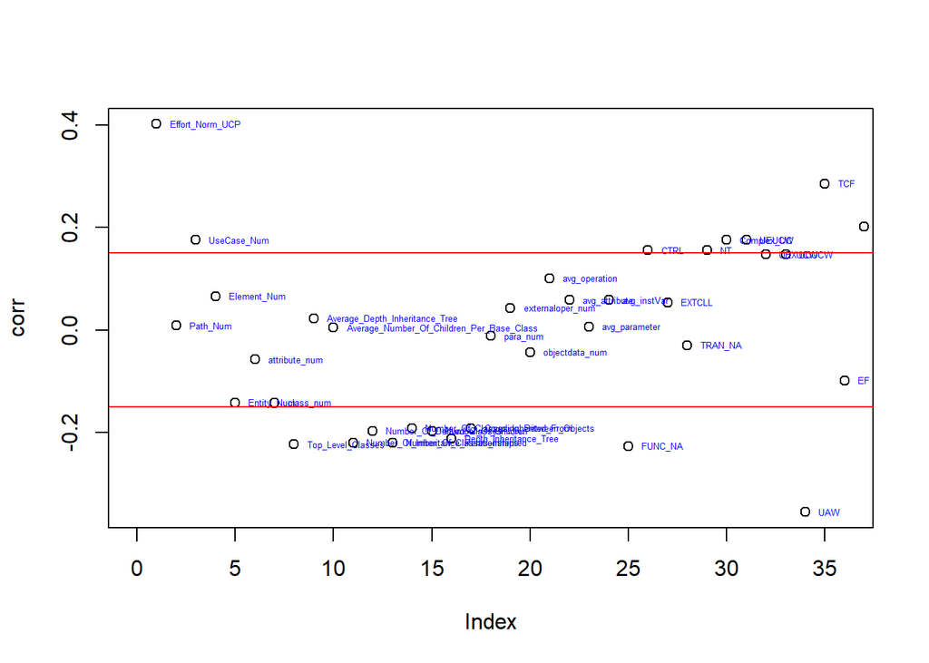

```r
corr <- cor(x,y)
plot(corr,xlim=c(0, 36))
text(1:42,corr,row.names(corr),cex=0.4, pos=4, col="blue")
abline(h=0.15,col="red")
abline(h=-0.15,col="red")
```

Looking at the graph, following are the most correlated independent variables:  
1. Effort_Norm_UCP 2. UseCase_Num 3. CTRL 4. NT 5. Complex_UC 6. UEUCW 7. TCF 8. EUCP 9. EXUCP 10. DUCP 11. Top_Level_Classes 12. Number_Of_Inheritance_Relationships 13. Number_Of_Derived_Classes 14. Number_Of_Classes_Inherited 15. Number_Of_Classes_Inherited_From 16. Number_Of_Children 17. Depth_Inheritance_Tree 18. Coupling_Between_Objects 19. FUNC_NA 20. UAW

## Model Fitting

```r
independentVar <- data.frame(x$Effort_Norm_UCP, x$UseCase_Num, x$CTRL, x$NT, x$Complex_UC, x$UEUCW, x$TCF, x$EUCP, x$EXUCP, x$DUCP, x$Top_Level_Classes, x$Number_Of_Inheritance_Relationships, x$Number_Of_Derived_Classes, x$Number_Of_Classes_Inherited, x$Number_Of_Classes_Inherited_From, x$Number_Of_Children, x$Depth_Inheritance_Tree, x$Coupling_Between_Objects, x$FUNC_NA, x$UAW)

names(independentVar)<- c("Effort_Norm_UCP","UseCase_Num","CTRL","NT","Complex_UC","UEUCW","TCF","EUCP","EXUCP","DUCP","Top_Level_Classes","Number_Of_Inheritance_Relationships","Number_Of_Derived_Classes","Number_Of_Classes_Inherited","Number_Of_Classes_Inherited_From","Number_Of_Children","Depth_Inheritance_Tree","Coupling_Between_Objects","FUNC_NA","UAW")

#library(caret)
#set.seed(30)
#model <- train(y~.,data=independentVar,method="lm",trControl = trainControl(method = "cv", number=2,verboseIter = TRUE))

fit <- lm(y~.,data=independentVar)
summary(fit)
```

```
##
## Call:
## lm(formula = y ~ ., data = independentVar)
##
## Residuals:
##      Min       1Q   Median       3Q      Max
## -1759.21  -415.50    -0.05   444.83  1246.70
##
## Coefficients: (7 not defined because of singularities)
##                                       Estimate Std. Error t value Pr(>|t|)
## (Intercept)                         -6292.7195  4421.6109  -1.423 0.172779
## Effort_Norm_UCP                         0.3669     0.2646   1.386 0.183525
## UseCase_Num                            41.2429   259.4861   0.159 0.875588
## CTRL                                   81.7000    64.7628   1.262 0.224155
## NT                                          NA         NA      NA       NA
## Complex_UC                                  NA         NA      NA       NA
## UEUCW                                       NA         NA      NA       NA
## TCF                                 10046.1378  5083.1322   1.976 0.064570
## EUCP                                   -5.8299    18.4307  -0.316 0.755616
## EXUCP                                 -43.6118    33.7428  -1.292 0.213484
## DUCP                                        NA         NA      NA       NA
## Top_Level_Classes                       2.7469    13.1427   0.209 0.836927
## Number_Of_Inheritance_Relationships -6531.0227  1302.5534  -5.014 0.000106
## Number_Of_Derived_Classes             616.5091   868.9024   0.710 0.487616
## Number_Of_Classes_Inherited                 NA         NA      NA       NA
## Number_Of_Classes_Inherited_From     -401.7018   265.8331  -1.511 0.149127
## Number_Of_Children                          NA         NA      NA       NA
## Depth_Inheritance_Tree               5538.6801  1349.9691   4.103 0.000742
## Coupling_Between_Objects                    NA         NA      NA       NA
## FUNC_NA                               -64.8707    30.6583  -2.116 0.049411
## UAW                                  -103.4690    58.7982  -1.760 0.096435
##
## (Intercept)
## Effort_Norm_UCP
## UseCase_Num
## CTRL
## NT
## Complex_UC
## UEUCW
## TCF                                 .
## EUCP
## EXUCP
## DUCP
## Top_Level_Classes
## Number_Of_Inheritance_Relationships ***
## Number_Of_Derived_Classes
## Number_Of_Classes_Inherited
## Number_Of_Classes_Inherited_From
## Number_Of_Children
## Depth_Inheritance_Tree              ***
## Coupling_Between_Objects
## FUNC_NA                             *
## UAW                                 .
## ---
## Signif. codes:  0 '***' 0.001 '**' 0.01 '*' 0.05 '.' 0.1 ' ' 1
##
## Residual standard error: 834.5 on 17 degrees of freedom
## Multiple R-squared:  0.8214, Adjusted R-squared:  0.6848
## F-statistic: 6.013 on 13 and 17 DF,  p-value: 0.000429
```

```r
raw_data <- read.csv(file = "./modelEvaluation_4_20_cleaned_1.csv", stringsAsFactors = F)
raw_data[is.na(raw_data[,"KSLOC"]), "KSLOC"] <- 0
```

```r
X_data = subset(raw_data, select = c("KSLOC","Path_Num","UseCase_Num","Element_Num",                                "Entity_Num","attribute_num","operation_num","class_num","Top_Level_Classes",                    "Average_Depth_Inheritance_Tree","Average_Number_Of_Children_Per_Base_Class",             "Number_Of_Inheritance_Relationships","Number_Of_Derived_Classes","Number_Of_Classes_Inherited", "Number_Of_Classes_Inherited_From","Number_Of_Children","Depth_Inheritance_Tree","Coupling_Between_Objects","para_num",         "externaloper_num","objectdata_num","avg_operation",          "avg_attribute","avg_parameter","avg_instVar",                               "FUNC_NA","EI","INT","DM","CTRL","EXTCLL","TRAN_NA","NT","Complex_UC","UEUCW",                "UEXUCW","UDUCW","UAW","TCF","EF","EUCP","EXUCP","DUCP","SWTI","SWTII","SWTIII"))
Y_data <- raw_data[,"Effort"]
```

```r
library(glmnet)
lasso_lm <- glmnet(x = data.matrix(X_data), y = as.vector(Y_data), alpha = 1, standardize = T)
```

```r
lasso_lm$lambda
```

```
##   [1] 518.491816 494.925563 472.430432 450.957740 430.461015 410.895897
##   [7] 392.220045 374.393038 357.376297 341.132993 325.627972 310.827678
##  [13] 296.700080 283.214604 270.342063 258.054599 246.325619 235.129740
##  [19] 224.442730 214.241462 204.503856 195.208841 186.336298 177.867025
##  [25] 169.782694 162.065809 154.699668 147.668329 140.956576 134.549882
##  [31] 128.434382 122.596841 117.024626 111.705676 106.628480 101.782051
##  [37]  97.155900  92.740014  88.524838  84.501247  80.660535  76.994389
##  [43]  73.494875  70.154420  66.965793  63.922095  61.016737  58.243432
##  [49]  55.596178  53.069246  50.657167  48.354720  46.156924  44.059020
##  [55]  42.056470  40.144938  38.320289  36.578573  34.916020  33.329033
##  [61]  31.814177  30.368174  28.987893  27.670349  26.412689  25.212191
##  [67]  24.066258  22.972410  21.928278  20.931604  19.980230  19.072098
##  [73]  18.205242  17.377786  16.587938  15.833991  15.114312  14.427343
##  [79]  13.771598  13.145657  12.548167  11.977833  11.433422  10.913756
##  [85]  10.417709   9.944208   9.492228   9.060792   8.648965   8.255856
##  [91]   7.880615   7.522429   7.180523   6.854157   6.542625   6.245252
##  [97]   5.961396   5.690441   5.431802   5.184918
```

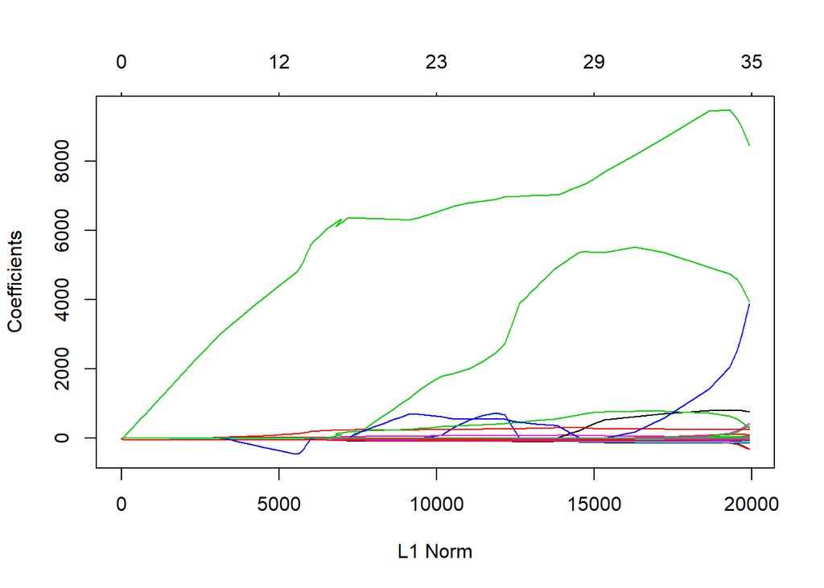

```r
plot(lasso_lm)
```

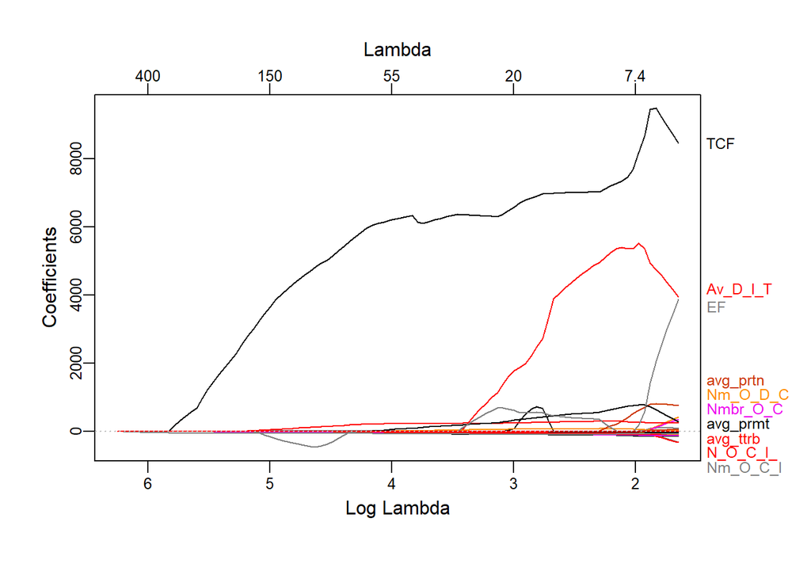

```r
library(plotmo) # for plot_glmnet
 #for 10 biggest final features
plot_glmnet(lasso_lm)                             # default colors
```

```r
#plot_glmnet(lasso_lm, label=10)
```

```r
Lasso_range = function(x, y, k){
  # inputs:
      # x_matrix, a matrix containing independent variables
      # y: vector of dependent varaibles
      # k: the length of sequence
  # output:
      # seq: a sequence of lambdaa from high to low


  # define my own scale function to simulate that in glmnet
  myscale = function(x) sqrt(sum((x - mean(x)) ^ 2) / length(x))

  # normalize x
  sx = as.matrix(scale(x, scale = apply(x, 2, myscale)))
  # sy = as.vector(scale(y, scale = myscale(y)))
  max_lambda = max(abs(colSums(sx * as.vector(y)))) / dim(sx)[1]
  # The default depends on the sample size nobs relative to the number of variables nvars.
  # If nobs > nvars, the default is 0.0001, close to zero.

  # If nobs < nvars, the default is 0.01.
  # A very small value of lambda.min.ratio will lead to a saturated fit in the nobs < nvars case.
  ratio = 0
  if(dim(sx)[1] > dim(sx)[2]){
    ratio = 0.0001
  }else{
    ratio = 0.01
  }
  min_lambda = max_lambda * ratio
  log_seq = seq(from  = log(min_lambda), to = log(max_lambda), length.out = k)
  seq = sort(exp(log_seq), decreasing = T)
  return(seq)
}
```

```r
Lasso_range(as.matrix(X_data),Y_data, 100)
```

```
##   [1] 518.491816 494.925563 472.430432 450.957740 430.461015 410.895897
##   [7] 392.220045 374.393038 357.376297 341.132993 325.627972 310.827678
##  [13] 296.700080 283.214603 270.342063 258.054599 246.325619 235.129739
##  [19] 224.442730 214.241461 204.503856 195.208840 186.336297 177.867025
##  [25] 169.782694 162.065809 154.699668 147.668329 140.956576 134.549882
##  [31] 128.434382 122.596841 117.024625 111.705676 106.628480 101.782051
##  [37]  97.155900  92.740014  88.524837  84.501247  80.660535  76.994389
##  [43]  73.494875  70.154420  66.965793  63.922094  61.016737  58.243432
##  [49]  55.596178  53.069246  50.657167  48.354720  46.156924  44.059020
##  [55]  42.056470  40.144938  38.320289  36.578573  34.916020  33.329033
##  [61]  31.814177  30.368174  28.987893  27.670349  26.412689  25.212191
##  [67]  24.066258  22.972410  21.928278  20.931604  19.980230  19.072098
##  [73]  18.205242  17.377785  16.587938  15.833991  15.114312  14.427343
##  [79]  13.771598  13.145657  12.548167  11.977833  11.433422  10.913756
##  [85]  10.417709   9.944208   9.492228   9.060792   8.648965   8.255856
##  [91]   7.880615   7.522428   7.180522   6.854157   6.542625   6.245252
##  [97]   5.961396   5.690441   5.431802   5.184918
```

```r
set.seed(2)
lambda_list <- Lasso_range(as.matrix(X_data),as.vector(Y_data),100)
percent = 50
cvfit = cv.glmnet(data.matrix(X_data),as.vector(Y_data),
                  standardize = T, type.measure = 'mse', nfolds = 5, alpha = 1)
# # 5 fold cross validation
 k <- 5
#
# function to calculate MMRE
calcMMRE <- function(testData,pred){
  mmre <- abs(testData - pred)/testData
  mean_value <- mean(mmre)
  mean_value
}
# # function to calculate PRED
calcPRED <- function(testData,pred,percent){
  value <- abs(testData - pred)/testData
  percent_value <- percent/100
  pred_value <- value <= percent_value
  mean(pred_value)
}
#
 folds <- cut(seq(1,nrow(X_data)),breaks=k,labels=FALSE)
 mean_mmre <- vector("list",k)
 mean_pred <- vector("list",k)
 overall_mean_mmre <- vector("list",100)
 overall_mean_pred <- vector("list",100)
 for(iterator in seq(1,100)){
   for(i in 1:k){
     testIndexes <- which(folds==i,arr.ind=TRUE)
     testData <- Y_data[testIndexes]
     pred <- predict(cvfit,newx=as.matrix(X_data),s=lambda_list[[iterator]])
     mean_mmre[[i]] <- calcMMRE(testData,pred[testIndexes])
     mean_pred[[i]] <- calcPRED(testData,pred[testIndexes],percent)
 }
 overall_mean_mmre[[iterator]] <- mean(as.numeric(mean_mmre))
 overall_mean_pred[[iterator]] <- mean(as.numeric(mean_pred))
 }
```

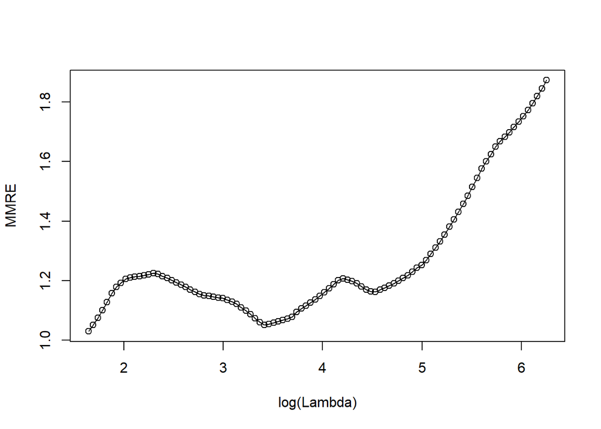

```r
plot(log(lambda_list),overall_mean_mmre,xlab="log(Lambda)",ylab="MMRE")
lines(log(lambda_list),overall_mean_mmre,xlim=range(log(lambda_list)), ylim=range(overall_mean_mmre), pch=16)
```

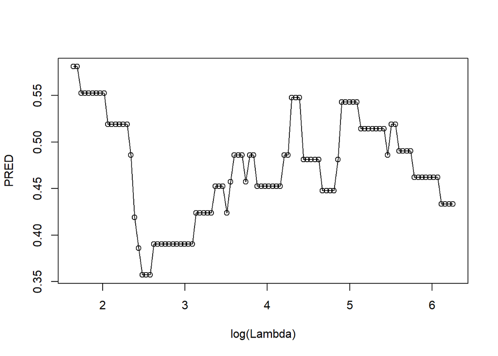

```r
plot(log(lambda_list),overall_mean_pred,xlab="log(Lambda)",ylab = "PRED")
lines(log(lambda_list),overall_mean_pred,xlim=range(log(lambda_list)), ylim=range(overall_mean_pred), pch=16)
```

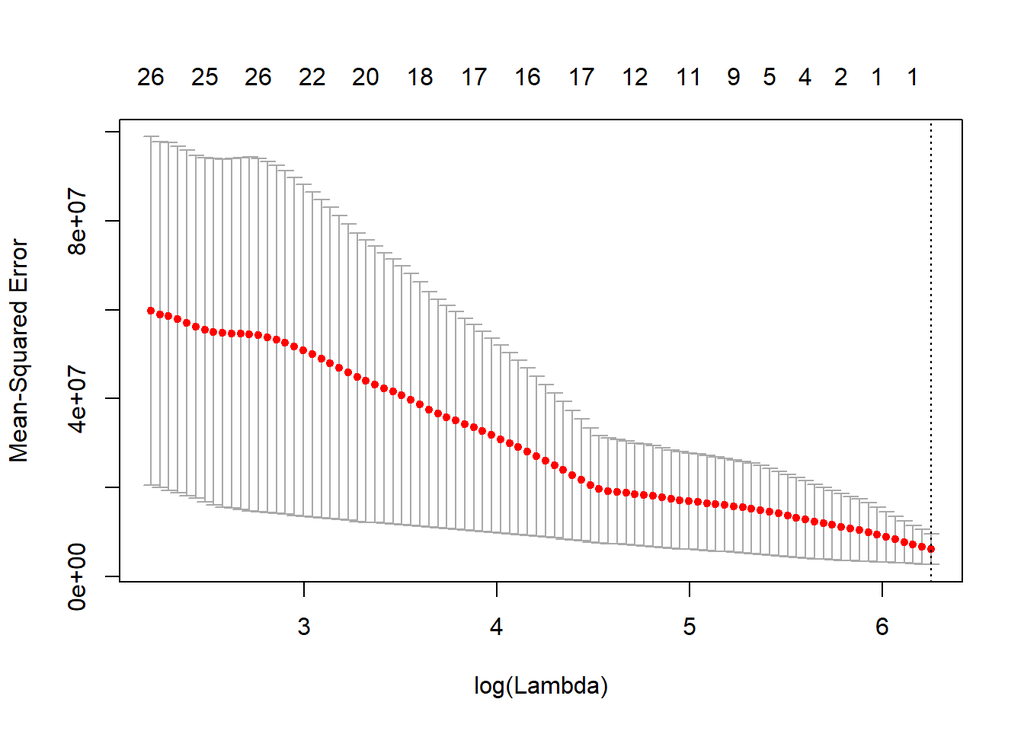

```r
plot(cvfit)
```